# Xue(Tracy) Feng - Text Analysis - Assignment 4

## Text Analysis - Assignment 4

## Sep 29, 2022

##### Building a Sentiment Analysis Pipeline

A common use case for text analytics is to use sentiment analysis. The growth of digital channels and options for data collection have expanded the ways that companies can monitor consumer sentiment and brand reputation.

Extracting insight from unstructured text data is one of the most valuable, but often challenging, tasks for organizations big and small. In this project, you have been assigned the task of collecting, processing, analyzing, and storing large amounts of text data to derive insight about your brand and competitors.

Your task is to build a text analytics sentiment analysis pipeline to use Python to extract, transform, load, and analyze Twitter data about five companies in a given industry. (Note it is not uncommon to encounter text analytics pipelines will use an extract-load-transform pipeline, with load coming before transform, to extract and load raw text into storage and then transform and analyze it on the way "out" of storage).

You should prepare a Jupyter notebook that contains all necessary code as well as Markdown text to explain each step of the process below, how it works, and what is happening. You will save the notebook as an HTML report and submit it to Canvas. The script should run without errors. You should use tables and/or visualizations to show your results. There should not be any long raw output printed to the page such as the raw response from the API.

### Question 1

##### Extract: Utilize the Twitter [API](https://developer.twitter.com/en/docs/twitter-api) v2 or [Tweepy](https://docs.tweepy.org/en/stable/) (which is just a Python wrapper for the Twitter API) to extract raw unstructured text about five companies.

```python
import requests
import pandas as pd
import numpy as np
import re
```

```python
def bearer_oauth(r):
    """
    Method required by bearer token authentication.
    """

    r.headers["Authorization"] = "Bearer AAAAAAAAAAAAAAAAAAAAABBnhQEAAAAAmj2TEQaHQWMXQnRUh7U3XkKbrcY%3DB7ojd6P5EYX3JvK3RiPumNBHJA1JO2i4CV4VrhplyoH7BumEVF"
    r.headers["User-Agent"] = "User"
    return r
```

```python
# return the output of the request
def getTweets(url, params, timeout=10):
    return requests.get(url = url,
            auth=bearer_oauth,
            params=params,
            timeout=timeout)
```

```python
company_list = ["Bytedance", "Tencent", "Porsche", "Walmart", "JPMorgan"]
```

```python
# combined the seperated code from previous questions into a function
def retrive_tweets(company):
    ### Set base URL and use requests library to issue get request
    # GET /2/tweets/search/recent
    # The recent search endpoint returns Tweets from the last seven days that match a search query.
    url = "https://api.twitter.com/2/tweets/search/recent"
    max_results = 100
    param = {"query": f'{company}',
                     "max_results": max_results}
    r = getTweets(url, param)
    return r.json()
```

```python
# store the output of raw unstructured text objects for 5 companies into the result list.
raw_text_list = []
for c in company_list:
    c_text = retrive_tweets(c)
    raw_text_list.append(c_text)
```

```python
# test the length of the result list
len(raw_text_list)
```

```
5
```

### Question 2

##### Transform: Process and clean the raw results from the API call to extract relevant information and text and create a dataframe of the results. Explain the processing steps you implement.

```python
# text processing and cleaning
def process_tweets(t):

    t = t.lower()
    t = re.sub("@[A-Za-z0-9]+", "", t) # remove handles
    t = re.sub("#[A-Za-z0-9]+", "", t) # remove hashtags
    t = re.sub(r"http\S+", "", t)      # remove links (anything that doesn't have a space after http)
    t = re.sub(r"www.\S+", "", t)      # remove links
    t = re.sub("[()!?]", "", t)        # remove punctuation
    t = re.sub("\[.*?\]", "", t)       # remove puncutation
    t = re.sub("[^a-z]", " ", t)
    return t
```

```python
# add only tweet texts for 5 comapnies to a list
tweets_five_companies = []
for c in raw_text_list:
    tweets_five_companies += [each["text"] for each in c["data"]]
```

```python
df_bytedance = pd.DataFrame([each["text"] for each in raw_text_list[0]["data"]])
df_tencent = pd.DataFrame([each["text"] for each in raw_text_list[1]["data"]])
df_porsche = pd.DataFrame([each["text"] for each in raw_text_list[2]["data"]])
df_walmart = pd.DataFrame([each["text"] for each in raw_text_list[3]["data"]])
df_jpmorgan = pd.DataFrame([each["text"] for each in raw_text_list[4]["data"]])
```

```python
# apply the text cleaning function to the data and generate a new column called "tweets_clean"
df_bytedance[0] = df_bytedance[0].apply(process_tweets)
df_tencent[0] = df_tencent[0].apply(process_tweets)
df_porsche[0] = df_porsche[0].apply(process_tweets)
df_walmart[0] = df_walmart[0].apply(process_tweets)
df_jpmorgan[0] = df_jpmorgan[0].apply(process_tweets)
```

```python
df_bytedance = df_bytedance.rename(columns={0: 'tweets'})
df_tencent = df_tencent.rename(columns={0: 'tweets'})
df_porsche = df_porsche.rename(columns={0: 'tweets'})
df_walmart = df_walmart.rename(columns={0: 'tweets'})
df_jpmorgan = df_jpmorgan.rename(columns={0: 'tweets'})
```

```python
frames = [df_bytedance, df_tencent, df_porsche, df_walmart, df_jpmorgan]
df_tweets_five_companies = pd.concat(frames, axis=1)
df_tweets_five_companies.columns = ["ByteDance", "Tencent", "Porsche", "Walmart", "JPMorgan"]
```

```python
df_tweets_five_companies.info()
```

```
<class 'pandas.core.frame.DataFrame'>
RangeIndex: 100 entries, 0 to 99
Data columns (total 5 columns):
 #   Column     Non-Null Count  Dtype
---  ------     --------------  -----
 0   ByteDance  100 non-null    object
 1   Tencent    100 non-null    object
 2   Porsche    100 non-null    object
 3   Walmart    100 non-null    object
 4   JPMorgan   100 non-null    object
dtypes: object(5)
memory usage: 4.0+ KB
```

```python
df_tweets_five_companies.head()
```

|  | ByteDance | Tencent | Porsche | Walmart | JPMorgan |
| --- | --- | --- | --- | --- | --- |
| 0 | rt meta bytedance ... | rt gina raimondo us secretary of commerce ... | rt ... | i love wacoms i have an intuos and a smalle... | fannie mae names former jpmorgan md priscilla ... |
| 1 | pico vr bytedance ... | rt china national radio and television admin... | rt ... | rt when you re walking past the aisles at wa... | rt |
| 2 | rt xi jinping has made it clear that he s t... | tencent tencent soft... | rt | rt when you re walking past the aisles at wa... | rt world s most admired companies for ... |
| 3 | rt wan zhang yiming has been spending mu... | rt china national radio and television admin... | rt drunk promo fairy doyoung doyoung b... | rt when you re walking past the aisles at wa... | rt whales per jpmorgan jpm |
| 4 | rt pico tiktok bytedance vr... | rt china national radio and television admin... | rt drunk doyoung is so funny heechul wor... | el walmart respondi ndome el tuit y le agrade... | rt whales per jpmorgan jpm |

### Question 3

##### Load: Create a SQL database to store the data in durable and persistent storage (for the purpose of this assignment, this can be a local database, but typically this will be a cloud storage option such as a database or object storage like S3 to use as a data lake un unstructured data)

```python
import sqlite3
```

```python
# Create a connection to the SQLite database
# Doesn't matter if the database does not yet exist
conn = sqlite3.connect('tweets_db.sqlite')
df_tweets_five_companies.to_sql('tweets', conn, if_exists='replace', index=False)
conn.close()
```

```python
# Reading SQLite table as a Pandas DataFrame
conn = sqlite3.connect('tweets_db.sqlite')
df = pd.read_sql_query('SELECT * FROM tweets', conn)
conn.close()
df.head()
```

|  | ByteDance | Tencent | Porsche | Walmart | JPMorgan |
| --- | --- | --- | --- | --- | --- |
| 0 | rt meta bytedance ... | rt gina raimondo us secretary of commerce ... | rt ... | i love wacoms i have an intuos and a smalle... | fannie mae names former jpmorgan md priscilla ... |
| 1 | pico vr bytedance ... | rt china national radio and television admin... | rt ... | rt when you re walking past the aisles at wa... | rt |
| 2 | rt xi jinping has made it clear that he s t... | tencent tencent soft... | rt | rt when you re walking past the aisles at wa... | rt world s most admired companies for ... |
| 3 | rt wan zhang yiming has been spending mu... | rt china national radio and television admin... | rt drunk promo fairy doyoung doyoung b... | rt when you re walking past the aisles at wa... | rt whales per jpmorgan jpm |
| 4 | rt pico tiktok bytedance vr... | rt china national radio and television admin... | rt drunk doyoung is so funny heechul wor... | el walmart respondi ndome el tuit y le agrade... | rt whales per jpmorgan jpm |

### Question 4

##### Analyze: Use text analytics techniques to analyze the processed text and compare companies and extract insight from public sentiment about the companies. Employ each of the following techniques to reveal insights in the text data and explain how to they can be used to inform business strategy and decision making.

WordClouds

Unigrams, bigrams, n-grams

Unlabeled sentiment analysis

Emotion classification

```python
from wordcloud import WordCloud
import matplotlib.pyplot as plt
```

```python
# A helper function to generate a string of words with punctuations removed
def word_str_generator(d):
    # initialize a new set to store all the single words from positive text reviews
    all_words_str = ""
    for column_name, s in d.iteritems():
        if s is not None:
            # split the current sentence
            temp_res = s.str.split()
            # append each word to the string with sapce as a seperator
            for w in temp_res:
                if w:
                    all_words_str = (" ").join(w)

    return all_words_str

# A helper function to display a wordcloud
def word_cloud_generator(s):
    wordcloud = WordCloud(background_color="white", width = 1000, height = 500).generate(s)
    plt.figure(figsize=(15,8))
    plt.imshow(wordcloud)
    plt.axis("off")
    plt.savefig("your_file_name"+".png", bbox_inches='tight')
    plt.show()
    plt.close()
```

#### Bytedance - WordClouds

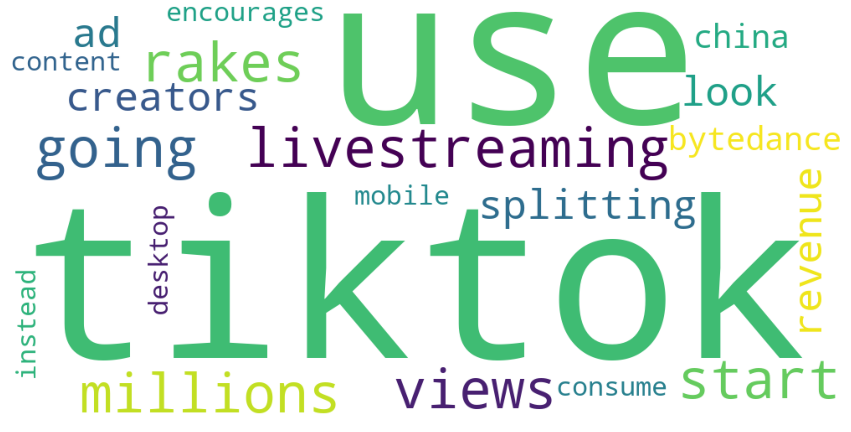

```python
#bytedance_df = df_tweets_five_companies.iloc[:100]
bytedance = word_str_generator(df_bytedance)
word_cloud_generator(bytedance)
```

#### Tencent - WordClouds

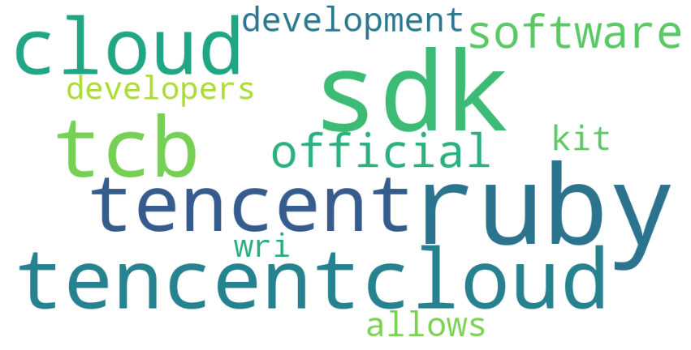

```python
tencent = word_str_generator(df_tencent)
word_cloud_generator(tencent)
```

#### Porsche - WordClouds

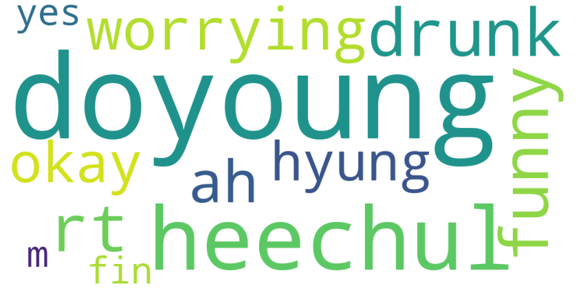

```python
porsche = word_str_generator(df_porsche)
word_cloud_generator(porsche)
```

#### Walmart - WordClouds

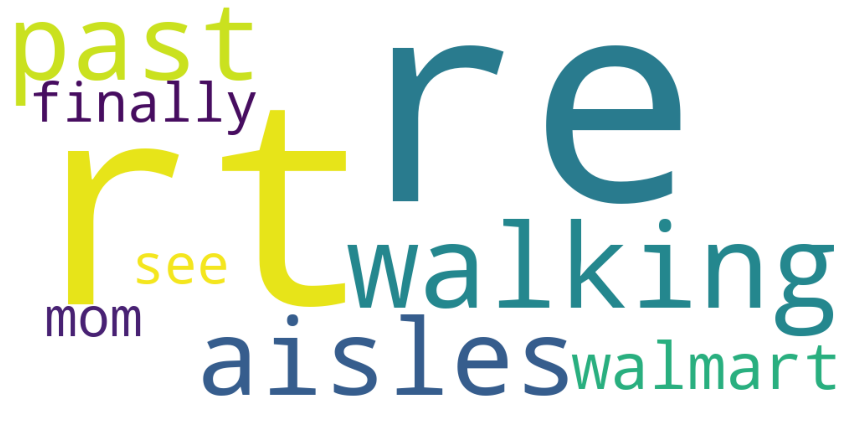

```python
walmart = word_str_generator(df_walmart)
word_cloud_generator(walmart)
```

#### JPMorgan - WordClouds

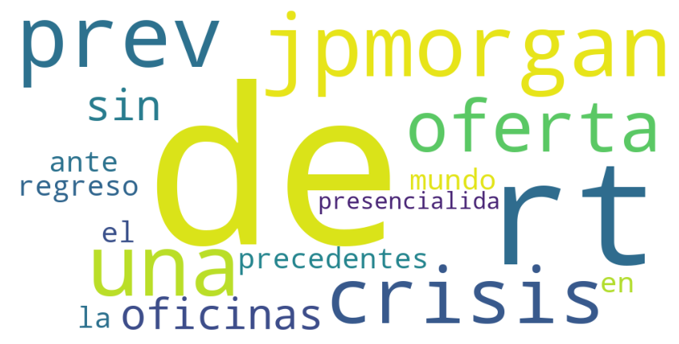

```python
jpmorgan = word_str_generator(df_jpmorgan)
word_cloud_generator(jpmorgan)
```

```python
from sklearn.feature_extraction.text import CountVectorizer
```

```python
# a helper function for getting n-grams
def get_ngrams(text, ngram_from=2, ngram_to=2, n=None, max_features=20000):

    vec = CountVectorizer(ngram_range = (ngram_from, ngram_to),
                          max_features = max_features,
                          stop_words='english').fit(text)
    bag_of_words = vec.transform(text)
    sum_words = bag_of_words.sum(axis = 0)
    words_freq = [(word, sum_words[0, i]) for word, i in vec.vocabulary_.items()]
    words_freq = sorted(words_freq, key = lambda x: x[1], reverse = True)

    return words_freq[:n]

# a helper function to vectorize the raw text
def vectorize(d, gram_name, ngram_from=1, ngram_to=1, n = 5):
    unigrams = get_ngrams(d.squeeze(), ngram_from, ngram_to, n)
    unigrams_df = pd.DataFrame(unigrams)
    unigrams_df.columns=[gram_name, "Frequency"]
    return unigrams_df.head()
```

```python
vectorize(df_bytedance, "ByteDance Unigram")
```

|  | ByteDance Unigram | Frequency |
| --- | --- | --- |
| 0 | bytedance | 121 |
| 1 | tiktok | 103 |
| 2 | meta | 101 |
| 3 | pico | 97 |
| 4 | rt | 72 |

```python
vectorize(df_tencent, "Tencent Unigram")
```

|  | Tencent Unigram | Frequency |
| --- | --- | --- |
| 0 | tencent | 70 |
| 1 | sdk | 54 |
| 2 | ruby | 54 |
| 3 | rt | 45 |
| 4 | cloud | 30 |

```python
vectorize(df_porsche, "Porsche Unigram")
```

|  | Porsche Unigram | Frequency |
| --- | --- | --- |
| 0 | rt | 87 |
| 1 | doyoung | 55 |
| 2 | porsche | 34 |
| 3 | heechul | 26 |
| 4 | baddies | 16 |

```python
vectorize(df_walmart, "Walmart Unigram")
```

|  | Walmart Unigram | Frequency |
| --- | --- | --- |
| 0 | walmart | 90 |
| 1 | rt | 83 |
| 2 | walking | 62 |
| 3 | past | 62 |
| 4 | aisles | 62 |

```python
vectorize(df_jpmorgan, "JPMorgan Unigram")
```

|  | JPMorgan Unigram | Frequency |
| --- | --- | --- |
| 0 | rt | 84 |
| 1 | los | 62 |
| 2 | jpmorgan | 38 |
| 3 | gregorio | 31 |
| 4 | rez | 31 |

```python
vectorize(df_bytedance, "ByteDance Bigram", 2, 2)
```

|  | ByteDance Bigram | Frequency |
| --- | --- | --- |
| 0 | tiktok bytedance | 44 |
| 1 | bytedance tiktok | 43 |
| 2 | pico tiktok | 42 |
| 3 | bytedance vr | 42 |
| 4 | pico meta | 42 |

```python
vectorize(df_tencent, "Tencent Bigram", 2, 2)
```

|  | Tencent Bigram | Frequency |
| --- | --- | --- |
| 0 | tencentcloud sdk | 27 |
| 1 | tencent cloud | 27 |
| 2 | cloud ruby | 27 |
| 3 | ruby sdk | 27 |
| 4 | sdk official | 27 |

```python
vectorize(df_porsche, "Porsche Bigram", 2, 2)
```

|  | Porsche Bigram | Frequency |
| --- | --- | --- |
| 0 | doyoung ah | 14 |
| 1 | rt drunk | 13 |
| 2 | doyoung hyung | 13 |
| 3 | drunk doyoung | 12 |
| 4 | doyoung funny | 12 |

```python
vectorize(df_walmart, "Walmart Bigram", 2, 2)
```

|  | Walmart Bigram | Frequency |
| --- | --- | --- |
| 0 | rt walking | 62 |
| 1 | walking past | 62 |
| 2 | past aisles | 62 |
| 3 | aisles walmart | 62 |
| 4 | walmart finally | 62 |

```python
vectorize(df_jpmorgan, "JPMorgan Bigram", 2, 2)
```

|  | JPMorgan Bigram | Frequency |
| --- | --- | --- |
| 0 | rt gregorio | 31 |
| 1 | gregorio rez | 31 |
| 2 | rez companc | 31 |
| 3 | companc mandaba | 31 |
| 4 | mandaba sus | 31 |

```python
vectorize(df_bytedance, "ByteDance 3-Grams", 5, 5)
```

|  | ByteDance 3-Grams | Frequency |
| --- | --- | --- |
| 0 | rt pico tiktok bytedance vr | 41 |
| 1 | pico tiktok bytedance vr meta | 41 |
| 2 | tiktok bytedance vr meta facebook | 41 |
| 3 | bytedance vr meta facebook quest | 41 |
| 4 | vr meta facebook quest bytedance | 41 |

```python
vectorize(df_tencent, "Tencent 3-Grams", 5, 5)
```

|  | Tencent 3-Grams | Frequency |
| --- | --- | --- |
| 0 | tencent cloud ruby sdk official | 27 |
| 1 | cloud ruby sdk official software | 27 |
| 2 | ruby sdk official software development | 27 |
| 3 | sdk official software development kit | 27 |
| 4 | official software development kit allows | 27 |

```python
vectorize(df_porsche, "Porsche 3-Grams", 5, 5)
```

|  | Porsche 3-Grams | Frequency |
| --- | --- | --- |
| 0 | rt drunk doyoung funny heechul | 12 |
| 1 | drunk doyoung funny heechul worrying | 12 |
| 2 | doyoung funny heechul worrying doyoung | 12 |
| 3 | funny heechul worrying doyoung ah | 12 |
| 4 | heechul worrying doyoung ah okay | 12 |

```python
vectorize(df_walmart, "Walmart 3-Grams", 5, 5)
```

|  | Walmart 3-Grams | Frequency |
| --- | --- | --- |
| 0 | rt walking past aisles walmart | 62 |
| 1 | walking past aisles walmart finally | 62 |
| 2 | past aisles walmart finally mom | 62 |
| 3 | rt just announced million grants | 3 |
| 4 | just announced million grants local | 3 |

```python
vectorize(df_jpmorgan, "JPMorgan 3-Grams", 5, 5)
```

|  | JPMorgan 3-Grams | Frequency |
| --- | --- | --- |
| 0 | rt gregorio rez companc mandaba | 31 |
| 1 | gregorio rez companc mandaba sus | 31 |
| 2 | rez companc mandaba sus hijos | 31 |
| 3 | companc mandaba sus hijos los | 31 |
| 4 | mandaba sus hijos los os | 31 |

#### Bytedance - Unlabeled sentiment analysis

```python
# Import transformers pipeline
from textblob import TextBlob
```

```python
# Analyze each line for sentiment
df_bytedance["sentiment"] = [TextBlob(each).sentiment.polarity for each in df_bytedance['tweets']]
df_bytedance["label"] = np.where(df_bytedance["sentiment"] > 0, "Positive", "Negative")
```

```python
# Examine and add some color to the results
df_bytedance[["tweets", "sentiment","label"]].head(10).style.background_gradient()
```

|  | tweets | sentiment | label |
| --- | --- | --- | --- |
| 0 | rt meta bytedance ms | 0.000000 | Negative |
| 1 | pico vr bytedance | 0.000000 | Negative |
| 2 | rt xi jinping has made it clear that he s trying to build this new society that will be driven by this total surveillance st | 0.078788 | Positive |
| 3 | rt wan zhang yiming has been spending much of this year overseas using singapore as a primary base his prolonged absence fr | -0.082500 | Negative |
| 4 | rt pico tiktok bytedance vr meta facebook quest bytedance tiktok pico meta | 0.000000 | Negative |
| 5 | rt certains entrepreneurs de la semblent vouloir se faire oublier et se tenir l cart de la m re patrie syndrome | 0.000000 | Negative |
| 6 | certains entrepreneurs de la semblent vouloir se faire oublier et se tenir l cart de la m re patrie syndrome jack ma | 0.000000 | Negative |
| 7 | rt pico tiktok bytedance vr meta facebook quest bytedance tiktok pico meta | 0.000000 | Negative |
| 8 | rt xi jinping has made it clear that he s trying to build this new society that will be driven by this total surveillance st | 0.078788 | Positive |
| 9 | rt pico tiktok bytedance vr meta facebook quest bytedance tiktok pico meta | 0.000000 | Negative |

#### Tencent - Unlabeled sentiment analysis

```python
df_tencent["sentiment"] = [TextBlob(each).sentiment.polarity for each in df_tencent['tweets']]
df_tencent["label"] = np.where(df_bytedance["sentiment"] > 0, "Positive", "Negative")
# Examine and add some color to the results
df_tencent[["tweets", "sentiment","label"]].head(10).style.background_gradient()
```

|  | tweets | sentiment | label |
| --- | --- | --- | --- |
| 0 | rt gina raimondo us secretary of commerce just said in a chat hosted by the atlantic council that us soldiers hav | 0.000000 | Negative |
| 1 | rt china national radio and television administration original streaming programs outstanding series our times distr | 0.437500 | Negative |
| 2 | tencent tencent software source application as cygwinpackage repository | 0.000000 | Positive |
| 3 | rt china national radio and television administration original streaming programs outstanding series our times distr | 0.437500 | Negative |
| 4 | rt china national radio and television administration original streaming programs outstanding series our times distr | 0.437500 | Negative |
| 5 | tencent big | 0.000000 | Negative |
| 6 | rt tencent | 0.000000 | Negative |
| 7 | rt tencent video weibo update good morning pd kun let s go to class together kun x campus go | 0.700000 | Negative |
| 8 | rt want to pitch a concept to tencent where they basically just do chuang again but with debuted idols and no rankings no el | 0.000000 | Positive |
| 9 | rt china national radio and television administration original streaming programs outstanding series our times distr | 0.437500 | Negative |

#### Porsche - Unlabeled sentiment analysis

```python
df_porsche["sentiment"] = [TextBlob(each).sentiment.polarity for each in df_porsche['tweets']]
df_porsche["label"] = np.where(df_bytedance["sentiment"] > 0, "Positive", "Negative")
# Examine and add some color to the results
df_porsche[["tweets", "sentiment","label"]].head(10).style.background_gradient()
```

|  | tweets | sentiment | label |
| --- | --- | --- | --- |
| 0 | rt | 0.000000 | Negative |
| 1 | rt | 0.000000 | Negative |
| 2 | rt | 0.000000 | Positive |
| 3 | rt drunk promo fairy doyoung doyoung baddies x i can go after talking about baddies a lot baddies baddies | -0.500000 | Negative |
| 4 | rt drunk doyoung is so funny heechul worrying doyoung ah are you okay doyoung hyung heechul yes doyoung i m fin | 0.083333 | Negative |
| 5 | rt cuando no est satisfecho saca su arma para amenazar a su gente y por el contrario jj no se acord de una l nea del | 0.000000 | Negative |
| 6 | rt grabe nga porsche | 0.000000 | Negative |
| 7 | rt mer hide you in my treasure chest kimchay kimporchay kimtwins mafia au multi chaptered porsche gets a new job very muc | 0.168182 | Negative |
| 8 | rt | 0.000000 | Positive |
| 9 | rt | 0.000000 | Negative |

#### Walmart - Unlabeled sentiment analysis

```python
df_walmart["sentiment"] = [TextBlob(each).sentiment.polarity for each in df_walmart['tweets']]
df_walmart["label"] = np.where(df_bytedance["sentiment"] > 0, "Positive", "Negative")
# Examine and add some color to the results
df_walmart[["tweets", "sentiment","label"]].head(10).style.background_gradient()
```

|  | tweets | sentiment | label |
| --- | --- | --- | --- |
| 0 | i love wacoms i have an intuos and a smaller less complicated one the small wacom one looks like might be good for a beginner it looks like there are some at walmart for | 0.047222 | Negative |
| 1 | rt when you re walking past the aisles at walmart and finally see your mom | -0.125000 | Negative |
| 2 | rt when you re walking past the aisles at walmart and finally see your mom | -0.125000 | Positive |
| 3 | rt when you re walking past the aisles at walmart and finally see your mom | -0.125000 | Negative |
| 4 | el walmart respondi ndome el tuit y le agradezco por la serotonina a cada que voy | 0.000000 | Negative |
| 5 | rt when you re walking past the aisles at walmart and finally see your mom | -0.125000 | Negative |
| 6 | rt when you re walking past the aisles at walmart and finally see your mom | -0.125000 | Negative |
| 7 | the american one is pure gameplay so they can put it on every tv in walmart | 0.107143 | Negative |
| 8 | rt and just announced up to million in grants to as well as local organizations on th | 0.000000 | Positive |
| 9 | went to walmart jus for some lotion | 0.000000 | Negative |

#### GPMorgan - Unlabeled sentiment analysis

```python
df_jpmorgan["sentiment"] = [TextBlob(each).sentiment.polarity for each in df_jpmorgan['tweets']]
df_jpmorgan["label"] = np.where(df_bytedance["sentiment"] > 0, "Positive", "Negative")
# Examine and add some color to the results
df_jpmorgan[["tweets", "sentiment","label"]].head(10).style.background_gradient()
```

|  | tweets | sentiment | label |
| --- | --- | --- | --- |
| 0 | fannie mae names former jpmorgan md priscilla almodovar as new ceo by reuters | 0.068182 | Negative |
| 1 | rt | 0.000000 | Negative |
| 2 | rt world s most admired companies for apple amazon microsoft pfizer walt disney berks | 0.500000 | Positive |
| 3 | rt whales per jpmorgan jpm | 0.000000 | Negative |
| 4 | rt whales per jpmorgan jpm | 0.000000 | Negative |
| 5 | rt software engineers amp data scientists from major cities have come together in for jpmorgan s firmwide softwar | 0.062500 | Negative |
| 6 | rt cabadi jpmorgan s digital bank chase uk hits mn customers financial times | 0.000000 | Negative |
| 7 | rt world s most admired companies for apple amazon microsoft pfizer walt disney berks | 0.500000 | Negative |
| 8 | rt gregorio p rez companc mandaba a sus hijos a los a os a hacer fotocopias servir caf esencialmente ser los che pibe | 0.000000 | Positive |
| 9 | rt gregorio p rez companc mandaba a sus hijos a los a os a hacer fotocopias servir caf esencialmente ser los che pibe | 0.000000 | Negative |

```python
# helper function for emotion recognition
def emotion_recog(text):
    import re
    import pandas as pd
    from transformers import AutoTokenizer, AutoModelWithLMHead
    import torch
    import sentencepiece

    # Extract the tokenizer from this model on Hugging Face Model Hub (will download first time you run it)
    tokenizer = AutoTokenizer.from_pretrained("mrm8488/t5-base-finetuned-emotion")

    # Extract the body from this model on Hugging Face Model Hub (will download first time you run it)
    model = AutoModelWithLMHead.from_pretrained("mrm8488/t5-base-finetuned-emotion")

    # Generate sequence of tensors (akin to multidimensional arrays) for input text
    inputs = tokenizer.encode(text,
                              return_tensors = "pt")

    # Generates sequences of token ids for models with a language modeling head.
    outputs = model.generate(input_ids = inputs,
                             max_length = 2)

    # Extract the emotion classification decoded output
    decoded = [tokenizer.decode(ids) for ids in outputs]

    # Extract just the emotion label, remove padding
    emotion_label = decoded[0]
    label = re.sub(f".", "", emotion_label, count = 6)

    return label
```

```python
# Test function on ByteDance
# df_bytedance["emotion"] = df_bytedance["tweets"].apply(emotion_recog)
```

[output not shown]

The above text analysis techniques can be used to achieve many business goals. For example, customer reviews using text analysis will add value to the product. Through results of text analysis, sellers will know where their product did bad, where to improve the product and how to make the reviews become more positive. They can also know which product is the most popular so they would know how many to produce and don't need to set a fixed number and support the block chain become more smooth. Customer reviews can help customers learn more about the product and determine whether it is suitable for them. Customer reviews should provide customers with real product feedback from other shoppers.

### Question 6

##### Explain how this sentiment analysis pipeline could be useful for (1) marketing analytics; (2) customer analytics; and (3) finance analytics (e.g. monitoring stock market trends).

1) Marketing Analytics - The sentiment analysis pipeline may be useful for marketing analysis because it is very suitable for market research and brand reputation monitoring. When companies conduct market research, sentiment analysis will enable them to understand customers' attitudes towards their products. Marketing data comes from different sources in various formats: website participation, CRM, email chain, in store system, click stream, social media data, etc. The analysis pipline solves the complex problem of unifying and standardizing these data, making it easy to analyze and measure customer participation across channels.

2) Customer Analytics - The sentiment analysis for customer reviews allows both the business itself and their potential customers can see an overview of what’s good, what’s lacking. Customer sentiment analysis can help the brand in a more feasible way. It can pick out which customers need additional care from a large number of feedback. They may mention issues such as payment, repeated frustration with call centers, or plans to cancel services. Tracking such topics and introducing the required processes is the key to closing the cycle: from receiving feedback to determining which actions will lead to a positive customer experience.

3) Finance Analytics - The financial analysis sentiment analysis pipeline is very important for the stock market, because the stock market often reacts to key events in the world. Today, it is not uncommon for key events to be first reported on social media, rather than by news organizations. In other words, investors can quickly obtain first-hand business intelligence through sentiment analysis channels. In addition, the rise and fall of the stock market largely depends on the confidence of investors and consumers. If the sentiment analysis pipeline is used, social media can become an excellent platform for in-depth understanding of consumer confidence.